# Regression Theory

### Example of Variable transformation (s25)

A bioengineer measures the growth rate of a substance by counting the number of cells $N$ present at various times $t$ as shown below. Fit the model $N=\gamma_0e^{\gamma_1t}$ and calculate two-sided 95% confidence intervals for the unknown parameters $\gamma_1$

| time | Num_cell |
| --- | --- |
| 1 | 12 |
| 2 | 31 |
| 3 | 42 |
| 4 | 75 |
| 5 | 119 |
| 6 | 221 |
| 7 | 327 |
| 8 | 546 |

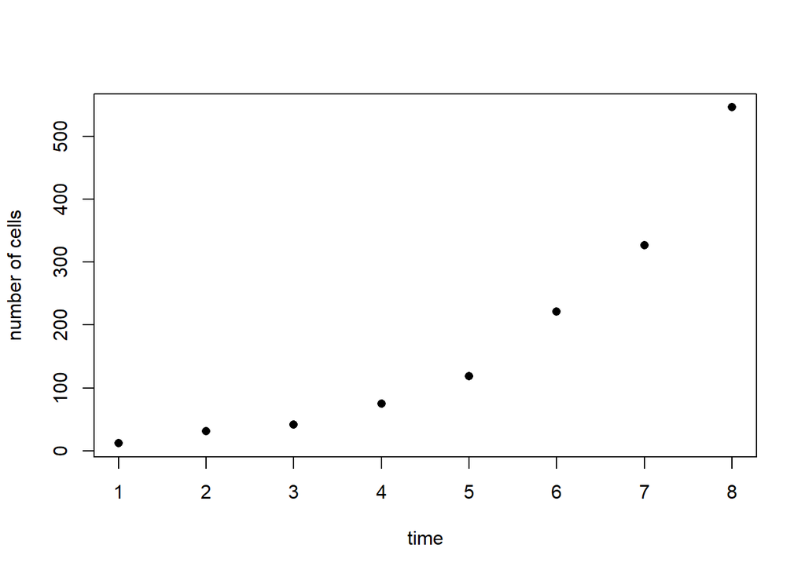

**Solution** with two unknown parameters $\gamma_0$ and $\gamma_1$ is commonly used for this problem. With a logarithmic transformation, the linear relationship
$$y = \beta_0 + \beta_1 x$$
is obtained with $y = ln(N)$, $\beta_0 = ln(\gamma_0)$, $\beta_1 = \gamma_1$, $x = t$.

```r
cell_growth <- data.frame(time = 1:8, Num_cell = c(12, 31, 42, 75, 119, 221, 327, 546))

# transform of variables
cell_growth$lnt <- log(cell_growth$time)
cell_growth$lnN <- log(cell_growth$Num_cell)

# fit linear model directly
model1 <- lm(Num_cell ~ time, data = cell_growth)
summary(model1)
```

```
##
## Call:
## lm(formula = Num_cell ~ time, data = cell_growth)
##
## Residuals:
##    Min     1Q Median     3Q    Max
## -87.14 -56.16 -21.64  44.47 132.75
##
## Coefficients:
##             Estimate Std. Error t value Pr(>|t|)
## (Intercept)  -139.04      64.20  -2.166  0.07350 .
## time           69.04      12.71   5.430  0.00162 **
## ---
## Signif. codes:  0 '***' 0.001 '**' 0.01 '*' 0.05 '.' 0.1 ' ' 1
##
## Residual standard error: 82.39 on 6 degrees of freedom
## Multiple R-squared:  0.8309, Adjusted R-squared:  0.8027
## F-statistic: 29.49 on 1 and 6 DF,  p-value: 0.001617
```

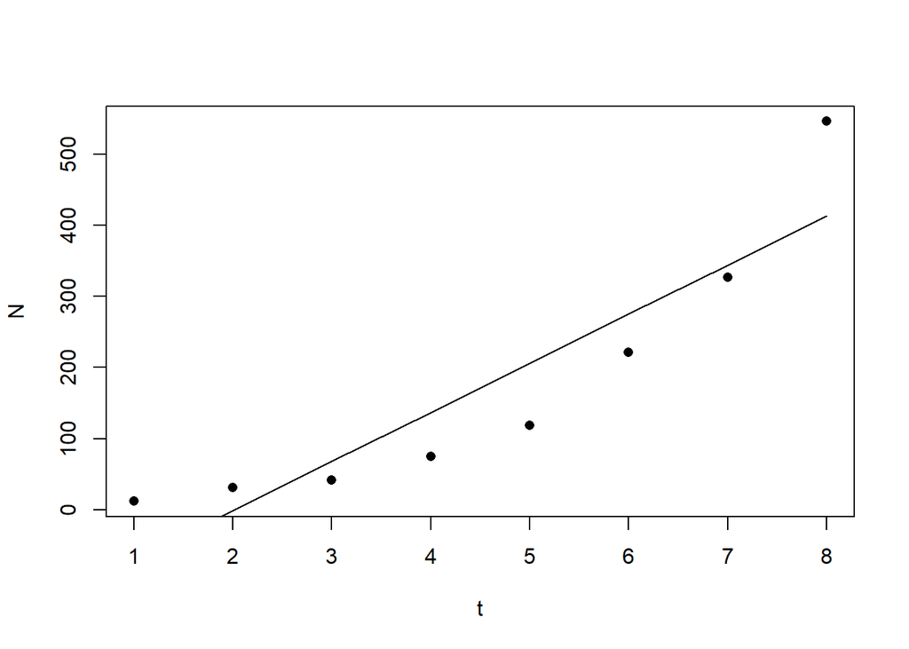

```r
plot(Num_cell ~ time, data = cell_growth, pch = 16,
     ylab = "N", xlab = "t")
lines(cell_growth$time, model1$fitted.values)
```

```r
# fit linear model with transformed variable
model2 <- lm(lnN ~ time, data = cell_growth)
summary(model2)
```

```
##
## Call:
## lm(formula = lnN ~ time, data = cell_growth)
##
## Residuals:
##      Min       1Q   Median       3Q      Max
## -0.21446 -0.05110 -0.01050  0.05717  0.21144
##
## Coefficients:
##             Estimate Std. Error t value Pr(>|t|)
## (Intercept)  2.17619    0.10357   21.01 7.57e-07 ***
## time         0.52318    0.02051   25.51 2.39e-07 ***
## ---
## Signif. codes:  0 '***' 0.001 '**' 0.01 '*' 0.05 '.' 0.1 ' ' 1
##
## Residual standard error: 0.1329 on 6 degrees of freedom
## Multiple R-squared:  0.9909, Adjusted R-squared:  0.9893
## F-statistic: 650.7 on 1 and 6 DF,  p-value: 2.391e-07
```

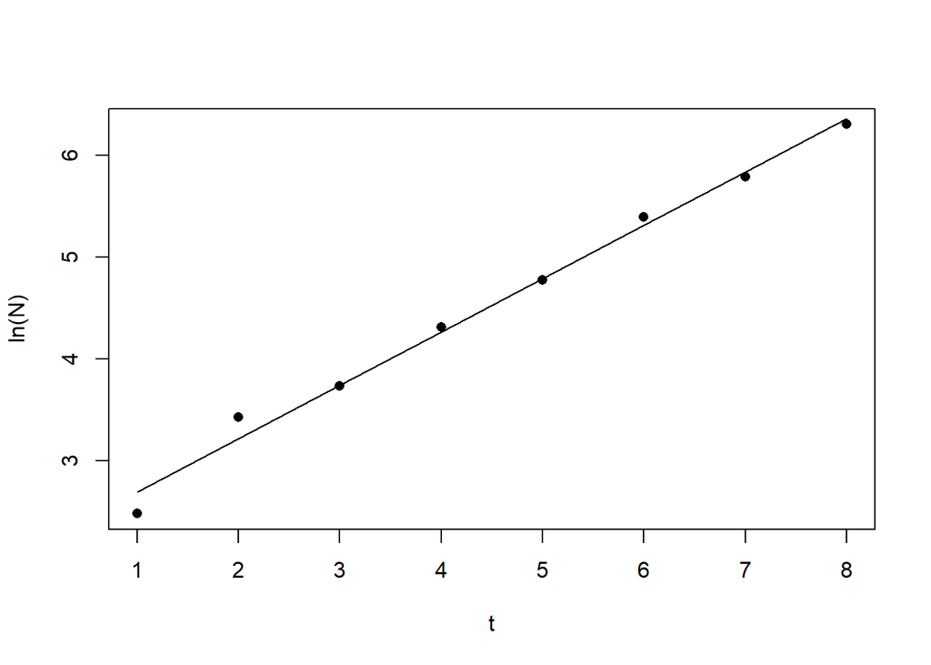

```r
plot(lnN ~ time, data = cell_growth, pch = 16,
     ylab = "ln(N)", xlab = "t")
lines(cell_growth$time, model2$fitted.values)
```

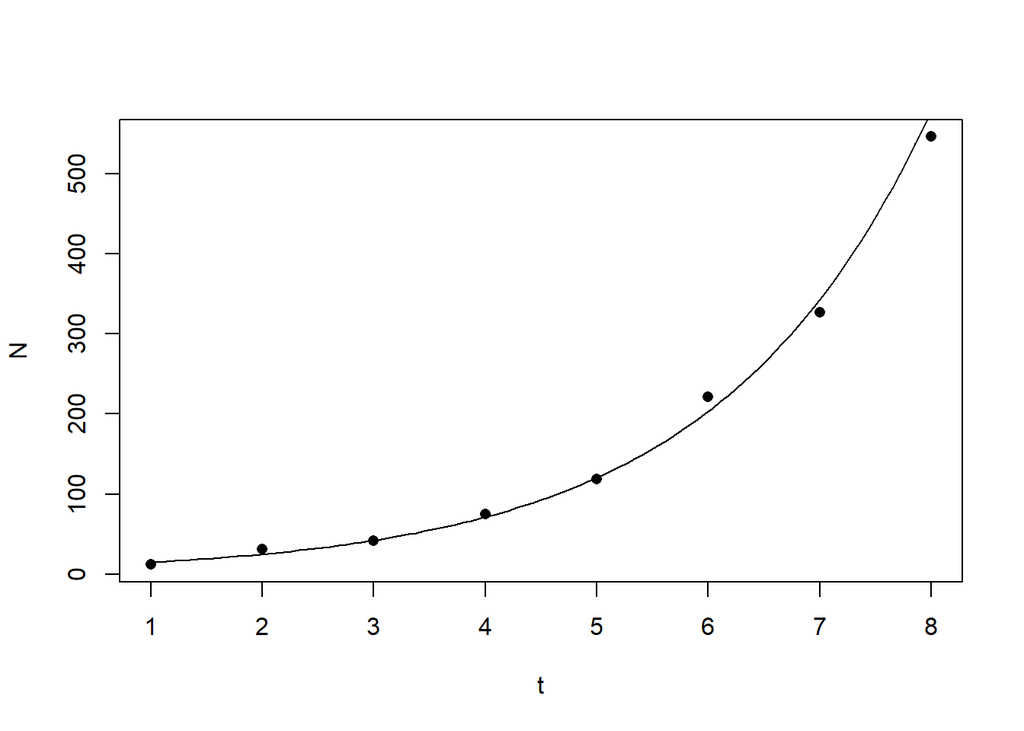

```r
slr <- function(x) exp(2.176 + 0.523*x)
plot(cell_growth$time, cell_growth$Num_cell, pch = 16,
     ylab = "N", xlab = "t")
curve(slr, add = TRUE)
```

```r
# confidence interval
confint(model2, "time", level=0.95)
```

```
##         2.5 %    97.5 %
## time 0.472994 0.5733623
```

## Summary example 1 - $V0_2-max$ Aerobic Fitness Measurements (s27, Hayter p560)

The table below is a data set concerning the aerobic fitness of a sample of 20 male subjects. An exercising individual breathes through an apparatus that measures the amount of oxygen in the inhaled air that is used by the individual. The maximum value per unit time of the utilized oxygen is then scaled by the person’s body weight to come up with a variable $VO_2-max$, which is a general indication of the aerobic fitness of the individual. In other words, $VO_2-max$ quantifies the maximum rate of oxygen consumption measured during incremental exercise. Fit a linear regression model with $VO_2-max$ as the dependent variable and age as the explanatory variable. Solve questions below.

| VO2.max | Age |
| --- | --- |
| 23 | 59 |
| 45 | 47 |
| 29 | 44 |
| 55 | 32 |
| 48 | 45 |
| 42 | 61 |
| 32 | 71 |
| 33 | 32 |
| 34 | 28 |
| 52 | 36 |
| 40 | 36 |
| 35 | 51 |
| 45 | 31 |
| 47 | 44 |
| 26 | 73 |
| 42 | 47 |
| 35 | 40 |
| 41 | 43 |
| 29 | 68 |
| 38 | 40 |

1. Estimate intercept ($\hat\beta_0$) and slope ($\hat\beta_1$) parameters.

```r
vo2 <- read.csv("http://bisyn.kaist.ac.kr/bis335/10-Regression-vo2max-aerobic-fitness.csv")

# prep
colnames(vo2) <- c("y", "x")
data <- vo2 %>% select(x, y) %>% mutate(xy = x*y, x2 = x^2, y2 = y^2)

# SS
n <- length(data$x)
SS <- colSums(data)
Sxx <- SS[4] - SS[1]^2/n
Syy <- SS[5] - SS[2]^2/n
Sxy <- SS[3] - SS[1]*SS[2]/n
knitr::kable(data.frame(Sxx = as.numeric(Sxx), Syy = as.numeric(Syy), Sxy = as.numeric(Sxy)))
```

| Sxx | Syy | Sxy |
| --- | --- | --- |
| 3486.8 | 1428.95 | -1177.4 |

```r
# Slope & Intercept
b1 <- Sxy/Sxx
b0 <- mean(data$y) - b1*mean(data$x)

knitr::kable(data.frame(intercept = as.numeric(round(b0,4)),
                        slope = as.numeric(round(b1,4))))
```

| intercept | slope |
| --- | --- |
| 54.2181 | -0.3377 |

2. Calculate $r^2$, $r$, and determine the significance of $r$ using $t$-statistic

```r
df <- n - 2
SSE <- as.numeric(Syy - b1*Sxy)
S2 <- SSE/df # error variance

# R^2 & r
SSR <- b1*Sxy
SST <- Syy
r2 <- SSR/SST
r <- Sxy/sqrt(Sxx*Syy)

# pvalue
t <- (r * sqrt(n-2))/(sqrt(1 - r^2))
t_crit <- qt(1-(a/2), df)
p <- 2 * pt(t, df, lower.tail = FALSE)

library(kableExtra)
kable(data.frame(S2 = as.numeric(round(S2,4)),
                        r2 = as.numeric(round(r2,4)),
                        r = as.numeric(round(r,4)),
                        sqrt_r2 = as.numeric(round(-sqrt(r2),4)),
                        p = as.numeric(round(p,4))),
             col.names = c("$S^2$", "$r^2$", "r", "$-\\sqrt {r^2}$", "p"),
             align = 'c', escape = FALSE, format = 'html', booktabs = TRUE) %>%
  kable_styling(position = "center")
```

[output not shown]

3. Find one-sided 95% confidence interval for $\hat\beta_1$

```r
a <- 0.05
t_crit <- qt(1 - a, df)
S <- sqrt(S2)
c11 <- 1/Sxx

upper <- b1 + (t_crit*S*sqrt(c11)); upper
```

```
##         xy
## -0.1153818
```

```r
kable(data.frame(lower = "-$\\infty$",
                 upper = as.numeric(round(upper,4))),
      escape = FALSE, align = 'c', format = 'html', booktabs = TRUE) %>%
  kable_styling(position = "center")
```

| lower | upper |
| --- | --- |
| -$\infty$ | -0.1154 |

4. Find two-sided 95% confidence and prediction interval for 50 years old male

```r
# Confidence interval
t_crit <- qt(1 - (a/2), df)
x <- 50
y_hat <- b0+b1*x
K <- (1/n)+((x - mean(vo2$x))^2/Sxx)

lower <- y_hat - (t_crit*S*sqrt(K))
upper <- y_hat + (t_crit*S*sqrt(K))

kable(data.frame(y_hat = as.numeric(round(y_hat, 4)),
                 lower = as.numeric(round(lower, 4)),
                 upper = as.numeric(round(upper,4))),
      col.names = c("$\\hat y$", "lower", "upper"),
      escape = FALSE, align = 'c', format = 'html', booktabs = TRUE) %>%
  kable_styling(position = "center")
```

| $\hat y$ | lower | upper |
| --- | --- | --- |
| 37.3344 | 33.6485 | 41.0202 |

```r
# Prediction interval
lower <- y_hat - (t_crit*S*sqrt(1+K))
upper <- y_hat + (t_crit*S*sqrt(1+K))

kable(data.frame(y_hat = as.numeric(round(y_hat, 4)),
                 lower = as.numeric(round(lower, 4)),
                 upper = as.numeric(round(upper,4))),
      col.names = c("$\\hat y$", "lower", "upper"),
      escape = FALSE, align = 'c', format = 'html', booktabs = TRUE) %>%
  kable_styling(position = "center")
```

| $\hat y$ | lower | upper |
| --- | --- | --- |
| 37.3344 | 21.0097 | 53.659 |

5. Using base R function, perform above analysis

```r
vo2 <- read.csv("http://bisyn.kaist.ac.kr/bis335/10-Regression-vo2max-aerobic-fitness.csv")

# 1. lm
fit <- lm(VO2.max ~ Age, data = vo2)
fit$coefficients # b0, b1
```

```
## (Intercept)         Age
##  54.2180509  -0.3376735
```

```r
# 2. r^2, r
## r^2
r2 <- summary(fit)
kable(data.frame(r2 = as.numeric(round(r2$r.squared, 4)),
                 f = as.numeric(round(r2$f[1], 4)),
                 p = as.numeric(round(r2$coefficients[2,4],4)),
                 sigma = as.numeric(round(r2$sigma,4))),
      col.names = c("$r^2$", "F", "p", "$\\hat\\sigma$"),
      escape = FALSE, align = 'c', format = 'html', booktabs = TRUE) %>%
  kable_styling(position = "center")
```

| $r^2$ | F | p | $\hat\sigma$ |
| --- | --- | --- | --- |
| 0.2782 | 6.9387 | 0.0168 | 7.5696 |

```r
## r, t, p
r <- cor.test(vo2$VO2.max, vo2$Age)

kable(data.frame(r = as.numeric(round(r$estimate, 4)),
                 t = as.numeric(round(r$statistic, 4)),
                 p = as.numeric(round(r$p.value,4))),
      col.names = c("$r$", "t", "p"),
      escape = FALSE, align = 'c', format = 'html', booktabs = TRUE) %>%
  kable_styling(position = "center")
```

| $r$ | t | p |
| --- | --- | --- |
| -0.5275 | -2.6341 | 0.0168 |

```r
# 3. conf.int for b1 (one-sided, upper)
confint(fit, "Age", level = 1-2*a, "one-sided")[2]
```

```
## [1] -0.1153818
```

```r
# 4. conf.int and pred.int for y_hat
newdata <- data.frame(Age = 50)
predict(fit, newdata, level=1-a, interval = "confidence")[1,]
```

```
##      fit      lwr      upr
## 37.33438 33.64853 41.02022
```

```r
predict(fit, newdata, level=1-a, interval = "prediction")[1,]
```

```
##      fit      lwr      upr
## 37.33438 21.00974 53.65901
```

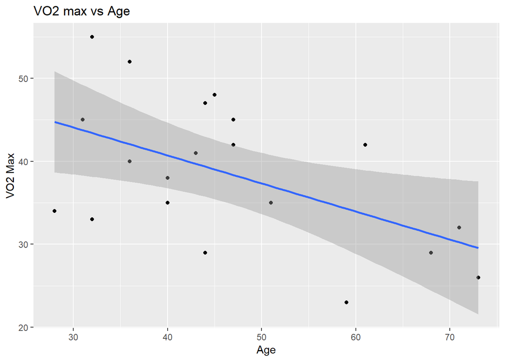

```r
# 5. visualize
library(ggplot2)
qplot(vo2$Age, vo2$VO2.max, ylab = "VO2 Max",
      xlab = "Age", main = "VO2 max vs Age") + stat_smooth(method = "lm")
```

6. Questions
- Does the sign of $\hat\beta_1$ surprise you? What does your model predict as the change in $VO2-max$ for an additional five years of age?
  $$-0.3377 \times 5 = -1.6885$$
- What does the model tell you about the aerobic fitness of a 15-year-old boy?

If the model is used then it would be extrapolation, so the prediction may be inaccurate.

## Summary example 2 - Initial mass of tumor vs Increased size of tumor

The following table summarize the initial ($S_0$) and increased masses of tumor ($S_1$) in a given time. From the scatter plot of the data set, you may notice that the relationship between $S_0$ and $S_1$ seems nonlinear. Find best linear fit of this data by using variable transformation and answer questions below. You can also test the variable $\Delta S = S_1 - S_0$ to find best fit between initial (possibly transformed) mass and difference or increased mass.

```r
tumor <- data_frame(s0 = c(55,55,80,80,105,105,130,155,155,180,180),
                    s1 = c(73,87,182,206,255,245,272,301,269,294,274))
kable(tumor, col.names = c("$S_0$", "$S_1$"),
      escape = FALSE, align = 'c', format = 'html', booktabs = TRUE) %>%
  kable_styling(position = "center")
```

| $S_0$ | $S_1$ |
| --- | --- |
| 55 | 73 |
| 55 | 87 |
| 80 | 182 |
| 80 | 206 |
| 105 | 255 |
| 105 | 245 |
| 130 | 272 |
| 155 | 301 |
| 155 | 269 |
| 180 | 294 |
| 180 | 274 |

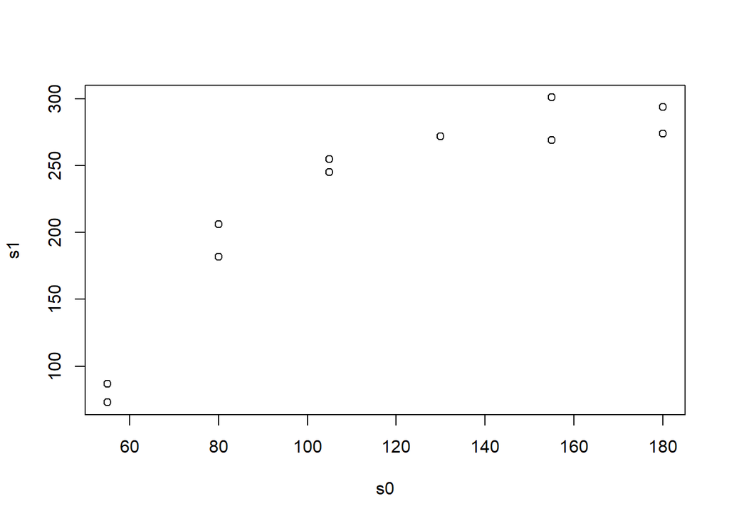

```r
plot(s1 ~ s0, data = tumor)
```

1. Calculate the $R^2$ for $(S_0, \Delta S)$, $(S_0, S_1)$

```r
# prep
tumor$sd <- tumor$s1 - tumor$s0

# reordering
fit1 <- lm(sd ~ s0, data = tumor)
fit2 <- lm(s1 ~ s0, data = tumor)

# r^2
summary(fit1)$r.squared
```

```
## [1] 0.2585808
```

```r
summary(fit2)$r.squared
```

```
## [1] 0.7649424
```

2. Perform appropriate variable transformation and calculate $R^2$ for $(S_0^*, \Delta S)$, $(S_0^*, S_1)$

```r
# prep
tumor$s0_t <- log(tumor$s0) # ln(s_0)

# reordering
fit3 <- lm(sd ~ s0_t, data = tumor)
fit4 <- lm(s1 ~ s0_t, data = tumor)

# r^2
summary(fit3)$r.squared
```

```
## [1] 0.4075046
```

```r
summary(fit4)$r.squared
```

```
## [1] 0.8827907
```

3. Test which variable pairs among the four relations above are significantly dependent with $\alpha$ level of 0.05 and 0.01.

```r
# Extract the statistic
t <- data.frame(fit1 = summary(fit1)$coefficients[2,3],
                fit2 = summary(fit2)$coefficients[2,3],
                fit3 = summary(fit3)$coefficients[2,3],
                fit4 = summary(fit4)$coefficients[2,3])

# Setting parameters
a1 <- 0.05
a2 <- 0.01
df <- length(tumor$s0)-2

# Calculate critical t (two-sided)
t_crit1 <- qt(1-(a1/2), df)
t_crit2 <- qt(1-(a2/2), df)

# result
t > t_crit1
```

```
##       fit1 fit2 fit3 fit4
## [1,] FALSE TRUE TRUE TRUE
```

```r
t > t_crit2
```

```
##       fit1 fit2  fit3 fit4
## [1,] FALSE TRUE FALSE TRUE
```

```r
# cf) R^2 cutoff
r2_crit1 <- t_crit1^2 / (t_crit1^2+df)
r2_crit2 <- t_crit2^2 / (t_crit2^2+df)

r2_crit <- data.frame(r2_crit1, r2_crit2); r2_crit
```

```
##    r2_crit1 r2_crit2
## 1 0.3624868 0.539911
```

Notice that for testing significance, $\hat\beta_1$ and r use the same t statistic. (see the theory part)

Recall that
$$R^2 = \frac{SSR}{SST} = 1 - \frac{SSE}{SST} = \frac{1}{1+\frac{SSE}{SSR}}$$
4. Test if there is the “lack of fit” to the models you created with significance level of 0.05 and 0.01

```r
library(alr3)
f_lof <- data.frame(fit1 = pureErrorAnova(fit1)[3,4],
                    fit2 = pureErrorAnova(fit2)[3,4],
                    fit3 = pureErrorAnova(fit3)[3,4],
                    fit4 = pureErrorAnova(fit4)[3,4])

# setting parameters
df1 <- pureErrorAnova(fit1)[3,1]
df2 <- pureErrorAnova(fit1)[4,1]
a1 <- 0.05
a2 <- 0.01

# critical F statistic
f_crit1 <- qf(1-a1, df1, df2)
f_crit2 <- qf(1-a2, df1, df2)

# result
f_lof > f_crit1
```

```
##      fit1 fit2 fit3 fit4
## [1,] TRUE TRUE TRUE TRUE
```

```r
f_lof > f_crit2
```

```
##      fit1 fit2 fit3  fit4
## [1,] TRUE TRUE TRUE FALSE
```

5. Calculate prediction interval of the model where $x_0 = \bar x$ and $x_0 = \bar x + 2S$ with significance level of 0.05

```r
# prep
S <- data.frame(fit1 = summary(fit1)$sigma,
                fit2 = summary(fit2)$sigma,
                fit3 = summary(fit3)$sigma,
                fit4 = summary(fit4)$sigma)
a <- 0.05

# for x0 = xbar
newdata.fit12 <- data.frame(s0 = mean(tumor$s0))
newdata.fit34 <- data.frame(s0_t = mean(tumor$s0_t))

# prediction interval for x0 = xbar
predict(fit1, newdata.fit12, level=1-a, interval = "prediction")[1,]
```

```
##       fit       lwr       upr
## 107.09091  11.46674 202.71508
```

```r
predict(fit2, newdata.fit12, level=1-a, interval = "prediction")[1,]
```

```
##      fit      lwr      upr
## 223.4545 127.8304 319.0787
```

```r
predict(fit3, newdata.fit34, level=1-a, interval = "prediction")[1,]
```

```
##       fit       lwr       upr
## 107.09091  21.60821 192.57361
```

```r
predict(fit4, newdata.fit34, level=1-a, interval = "prediction")[1,]
```

```
##      fit      lwr      upr
## 223.4545 155.9300 290.9791
```

```r
# for x0 = xbar + 2S
newdata.fit1 <- data.frame(s0 = mean(tumor$s0) + 2 * as.numeric(summary(fit1)$sigma))
newdata.fit2 <- data.frame(s0 = mean(tumor$s0) + 2 * as.numeric(summary(fit2)$sigma))
newdata.fit3 <- data.frame(s0_t = mean(tumor$s0_t) + 2 * as.numeric(summary(fit3)$sigma))
newdata.fit4 <- data.frame(s0_t = mean(tumor$s0_t) + 2 * as.numeric(summary(fit4)$sigma))

# prediction interval for x0 = xbar + 2S
predict(fit1, newdata.fit1, level=1-a, interval = "prediction")[1,]
```

```
##       fit       lwr       upr
## 146.48611  38.43892 254.53331
```

```r
predict(fit2, newdata.fit2, level=1-a, interval = "prediction")[1,]
```

```
##      fit      lwr      upr
## 343.7930 235.7458 451.8402
```

```r
predict(fit3, newdata.fit3, level=1-a, interval = "prediction")[1,]
```

```
##       fit       lwr       upr
## 4820.8822  534.0701 9107.6942
```

```r
predict(fit4, newdata.fit4, level=1-a, interval = "prediction")[1,]
```

```
##       fit       lwr       upr
##  9956.777  7281.596 12631.958
```

6. visulalize the best regression line in transformed space and original space.

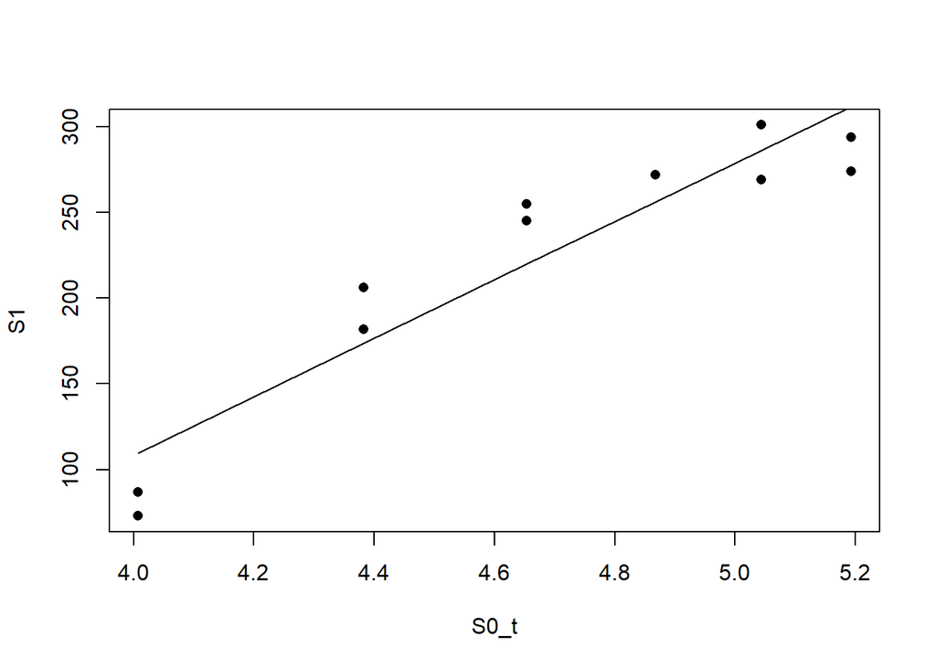

```r
# transformed space
plot(tumor$s0_t, tumor$s1, pch = 16, xlab = "S0_t", ylab = "S1")
lines(tumor$s0_t, fit4$fitted.values)
```

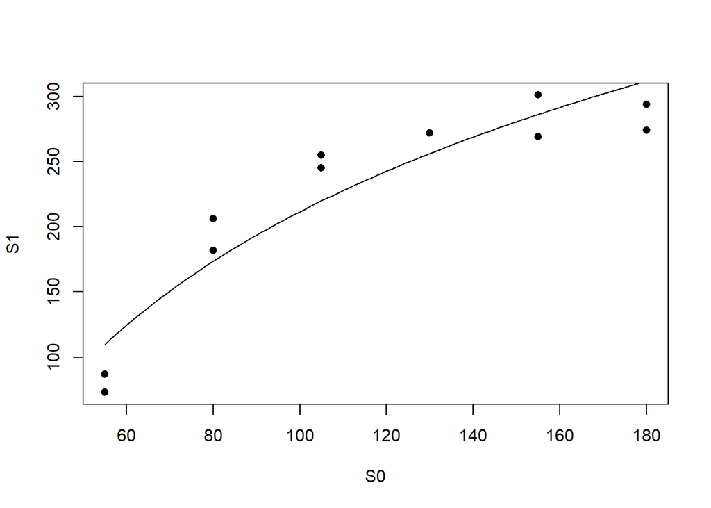

```r
# original space
slrv <- function(x){fit4$coefficients[2]*log(x)+fit4$coefficients[1]}
plot(tumor$s0, tumor$s1, pch = 16, xlab = "S0", ylab = "S1")
curve(slrv, add = TRUE)
```

## Simple linear regression with matrix notation

For $n$ observations from a simple linear model of the form
$$Y = \beta_0 + \beta_1 x + \epsilon$$
we have

$$Y = \begin{bmatrix} y_1 \\ y_2 \\ \vdots\\ y_n \end{bmatrix}, \hspace{1cm}
X = \begin{bmatrix} 1 & x_{1} \\
1 & x_{2} \\
\vdots & \vdots \\
1 & x_{n} \end{bmatrix}, \hspace{1cm}
\beta = \begin{bmatrix} \beta_0 \\ \beta_1 \end{bmatrix}, \hspace{1cm}
\epsilon = \begin{bmatrix} \epsilon_1 \\ \epsilon_2 \\ \vdots\\ \epsilon_n \end{bmatrix}$$

The least-squares equations for $\beta_0$ and $\beta_1$ were given below
$$n \hat\beta_0 + \hat\beta_1\sum_{i=1}^n x_i = \sum_{i=1}^n y_i, \hspace{1cm} \hat\beta_0\sum_{i=1}^n x_i + \hat\beta_1\sum_{i=1}^n x_i^2 = \sum_{i=1}^n x_iy_i$$
and because
$$X'X = \begin{bmatrix} 1 & 1 & \dots & 1 \\ x_1 & x_2 & \dots & x_n \end{bmatrix} \begin{bmatrix} 1 & x_1 \\ 1 & x_2 \\ \vdots & \vdots \\ 1 & x_n \end{bmatrix} = \begin{bmatrix} n & \sum_{i=1}^n x_i \\ \sum_{i=1}^n x_i & \sum_{i=1}^n x_i^2 \end{bmatrix}$$
and
$$X'Y = \begin{bmatrix} \sum_{i=1}^n y_i \\ \sum_{i=1}^n x_iy_i \end{bmatrix}$$
if
$$\hat\beta = \begin{bmatrix} \hat\beta_0 \\ \hat\beta_1 \end{bmatrix}$$
We see that the least-squares equations are given by
$$(X'X)\hat\beta = X'Y$$
Hence,
$$\hat\beta = (X'X)^{-1}X'Y$$

### Example of simple linear regression with matrix notation (Wackerly p611)

Use the matrix notation, perform simple linear regression with $n=5$ data points given in the table below.

| x | y |
| --- | --- |
| -2 | 0 |
| -1 | 0 |
| 0 | 1 |
| 1 | 1 |
| 2 | 3 |

**Solution**

We can see that
$$Y = \begin{bmatrix} 0 \\ 0 \\ 1 \\ 1 \\ 3 \end{bmatrix}, \hspace{1cm}
X = \begin{bmatrix} 1 & -2 \\
1 & -1 \\
1 &\phantom{-}0 \\
1 &\phantom{-}1 \\
1 &\phantom{-}2 \end{bmatrix}$$
It follows that

$$X'X =\begin{bmatrix} 5 & 0 \\ 0 & 10 \end{bmatrix}, \hspace{1cm} X'Y =\begin{bmatrix} 5 \\ 7 \end{bmatrix},\hspace{1cm} (X'X)^{-1} =\begin{bmatrix} 1/5 & 0 \\ 0 & 1/10 \end{bmatrix}$$
Thus,
$$\hat\beta = (X'X)^{-1}X'Y =\begin{bmatrix} 1/5 & 0 \\ 0 & 1/10 \end{bmatrix} \begin{bmatrix} 5 \\ 7 \end{bmatrix} =\begin{bmatrix} 1 \\ 0.7 \end{bmatrix}$$
or $\hat\beta_0 = 1$ and $\hat\beta_1 = 0.7$. Thus,
$$\hat y = 1+0.7x$$
just as the previous result.

```r
toy <- data.frame(x = c(-2,-1,0,1,2), y = c(0,0,1,1,3))

X <- as.matrix(data.frame(rep(1,5), toy$x))
Y <- as.matrix(toy$y)

tX_X <- t(X) %*% X
tX_Y <- t(X) %*% Y

inv_tx_x <- solve(tX_X) # inverse matrix

b <- inv_tx_x %*% tX_Y
b <- as.data.frame(t(b))

kable(b, col.names = c("$\\hat \\beta_0$", "$\\hat \\beta_1$"),
      escape = FALSE, align = 'c', format = 'html', booktabs = TRUE) %>%
  kable_styling(position = "center")
```

| $\hat \beta_0$ | $\hat \beta_1$ |
| --- | --- |
| 1 | 0.7 |

## Multiple linear regression (extra)

Suppose that we have the linear model
$$Y = \beta_0 + \beta_1 x_1 + ... + \beta_k x_k + \epsilon$$

and we make $n$ independent observations, $y_1, y_2, ..., y_n$, on $Y$. We can write the observation $y_i$ as
$$y_i = \beta_0 + \beta_1 x_{i1} + \beta_2 x_{i2} + ... + \beta_k x_{ik} + \epsilon_i$$
where $x_{ij}$ is the setting of the $j_{th}$ independent variable for the ${i_th}$ observation, $i=1,2,...,n$.

The coefficients $\beta_0, ..., \beta_k$ are unknown parameters, and the error terms $\epsilon_i, 1 \leq i \leq n$, are taken to be independent observations from a $N(0, \sigma^2)$ distribution.

The expected value of the response variable at $x = (x_1, ... , x_k)$ is
$$E(Y|x) = \beta_0 + \beta_1x_1 + ... + \beta_k x_k$$
For example, with k = 2 the expected values of the response variable lie on the plane $y = \beta_0 + \beta_1x_1 + \beta_2x_2$. The parameter $\beta_0$ is referred to as the intercept parameter, and the parameter $\beta_i$ determines how the $i_{th}$ input variable $x_i$ influences the response variable when the other input variables are kept fixed. If $\beta_i > 0$, then the expected value of the response variable increases as the ith input variable increases (with the other input variables kept fixed), and if $\beta_ < 0$, then the expected value of the response variable decreases as the ith input variable increases (with the other input variables kept fixed). If $\beta_i = 0$, then the response variable is not influenced by changes in the ith input variable (with the other input variables kept fixed).

To fit the MLR model, we use the method of least squares the same as in SLR model. with the normal distribution of the error terms $\epsilon_i$, the method of least squares produces the maximum likelihood estimates of the parameters. The sum of squares is

$$Q = \sum_{i=1}^n (y_i - (\beta_0 + \beta_1 x_{1i} + ... + \beta_kx_{ki}))^2$$
which can be minimized by taking derivatives with respect to each of the unknown parameters, setting the resulting expressions equal to 0, and then simultaneously solving the equations to obtain the parameter estimates $\hat\beta_i$. The derivative of $Q$ with respect to $\beta_0$ is

$$\frac{\partial Q}{\partial \beta_0} = -2 \sum_{i=1}^{n} (y_i - (\beta_0 + \beta_1 x_{1i}+...+\beta_kx_{ki}))$$
and the derivative of $Q$ with respect to $\beta_j$, $1\leq j\leq k$, is
$$\frac{\partial Q}{\partial \beta_0} = -2 \sum_{i=1}^{n} x_{ji} (y_i - (\beta_0 + \beta_1 x_{1i}+...+\beta_kx_{ki}))$$
Setting these expressions equal to 0 results in the $k + 1$ equations

$$\begin {aligned} \sum_{i=1}^n y_i &= n\beta_0 + \beta_1\sum_{i=1}^nx_{1i} + \beta_2\sum_{i=1}^nx_{2i} + ... + \beta_k\sum_{i=1}^nx_{ki}\\
\sum_{i=1}^n y_ix_{1i} &= \beta_0\sum_{i=1}^nx_{1i} + \beta_1\sum_{i=1}^nx_{1i}^2 + \beta_2\sum_{i=1}^nx_{2i}x_{1i} + ... + \beta_k\sum_{i=1}^nx_{ki}x_{1i} \\
& \vdots \\
\sum_{i=1}^n y_ix_{ki} &= \beta_0\sum_{i=1}^nx_{ki} + \beta_1\sum_{i=1}^nx_{1i}x_{ki}+ \beta_2\sum_{i=1}^nx_{2i}x_{ki} + ... + \beta_k\sum_{i=1}^nx_{ki}^2
\end{aligned}$$
The parameter estimates $\hat\beta_0, \hat\beta_1, \dots, \hat\beta_k$ are the solutions to these equations, which are known as the normal equations.

The fitted value of the response variable at the data point $(x_{1i}, ..., x_{ki})$ is
$$\hat y_i = \hat\beta_0 + \hat\beta_1 x_{1i} + \hat\beta_k x_{ki}$$
and the $i_{th}$ residual is
$$e_i = y_i - \hat y_i$$
As in simple linear regression, the sum of squares for error is defined to be
$$SSE = \sum_{i=1}^n (y_i-\hat y_i)^2 = \sum_{i=1}^n e_i^2$$
The estimate of the error variance $\sigma^2$ is
$$MSE = \hat\sigma^2 = \frac{SSE}{n-k-1}$$
(where the degrees of freedom for error $n-k-1$ are equal to the sample size $n$ minus the number of parameters estimated $k+1$), which is distributed as
$$\sigma^2 \sim \sigma^2 \frac{\chi^2_{n-k-1}}{n-k-1}$$

Also, as with simple linear regression th total sum of squares
$$SST = \sum_{i = 1}^n (y_i - \bar y)^2$$
can be composed as
$$SST = SSR + SSE$$
where the regression sum of squares is
$$SSR = \sum_{i=1}^n(\hat y_i - \bar y)^2$$
Differ from simple linear regression, For MLR, we now $k$ degrees of freedom for regression and $n-k-1$ degrees of freedom for error.

The $p-value$ in the analysis of variance table is for the numm hypothesis
$$H_0: \beta_1 = ... = \beta_k = 0$$
(with the alternative hypothesis that at least one of these $\beta_i$ is nonzero), which has the interpretation that the response variable is not related to any of the $k$ input variables. A large $p-vlaue$ therefore indicates that there is no evidence that any of the input variables affects the distribution of the response variable $y$. The cofficient of (multiple determination)
$$R^2 = \frac{SSR}{SST}$$
takes a value between 0 and 1 and indicates the amount of total variability in thevalues of the response variable that is accounted for by the fitted regression model. The F-statistic in the ANOVA table can be written as
$$F = \frac{(n-k-1)R^2}{k(1-R^2)}$$

A small $p-value$ in the analysis of variance table indicates that the response variable is related to at least one of the input variables. Computer output provides the user with the parameter estimates $\hat\beta_0, \hat\beta_1, \hat\beta_k$ together with their standard errors $s.e.(\hat\beta_0), s.e.(\hat\beta_1), ... , s.e.(\hat\beta_k)$ and these can be used to determine which input variables are needed in the regression model. If $\beta_i = 0$, then the distribution of the response variable does not directly depend on the input variable $x_i$, which can therefore be *“dropped”* from the model. Consequently, it is useful to test the hypotheses
$$H_0 : \beta_i = 0 \ \ versus \ \ H_A : \beta_i \neq 0$$
If the null hypothesis is accepted, then there is no evidence that the response variable is directly related to the input variable $x_i$, and it can therefore be *dropped* from the model. If the null hypothesis is rejected, then there is evidence that the response variable is related to the input variable, and it should therefore be kept in the model. These hypotheses are tested with the $t$-statistics
$$t = \frac{\hat\beta_i}{s.e.(\hat\beta_i)}$$
which are compared to a t-distribution with $n-k-1$ degrees of freedom. The (two-sided) $p-value$ is therefore
$$p-value = 2 \times P(X>|t|)$$
where the random variable $X$ has a $t$-ditsribution with $n-k-1$ degrees of freedom. If we dropped parameters from the model, we can test the significance of difference between original and modified model. Formally,
$$H_0: \beta_i = b_i \ \ versus \ \ H_A:\beta_i \neq b_i$$
for a fixed value of $b_i$ of interest can be tested with the $t$-statistic
$$t = \frac{\hat\beta_i - b_i}{s.e.(\hat\beta_i)}$$
which is again compared to a t-distribution with $n-k-1$ degrees of freedom.

Typically, model fitting may be performed in the following manner. First, an experimenter starts by fitting all $k$ input variables. If all variables are needed in the model, then no reduction is necessary. If one or more input variables has a p-value larger than $10\%$, the variable with the largest p-value (smallest absolute value of the t-statistic) is removed. The reduced model with $k-1$ input variables is then fitted, and the process is repeated. This is known as a backwards elimination modeling procedure and most computer packages will perform it automatically on request.

Alternatively, a forward selection modeling procedure can be employed whereby the model starts off without any variables, and input variables are then added one at a time until no further additions are needed. Most computer packages can also implement a stepwise procedure that is a combination of the backward elimination and forward selection procedures, and that allows either the addition of new variables or the removal of variables already in the model.

**Inferences on the response variable** Suppose that the final model includes the $k$ input variables $x_1, ..., x_k$ which may be only a subet of the inital set of input variables that were investigated. The fitted value of the response variable at a specific set of values of the input variables $x_i^*$ of interest is
$$\hat y|_{x^*} = \hat\beta_0 + \hat\beta_1x_1^* + ... + \hat\beta_kx_k^*$$
which is an estimate of the expected value of the response variable y at these values of the input variables. A $1-\alpha$ confidence level level confidence interval for the expected value of the response variable at $x_i^*$ is
$$\hat\beta_0 + \hat\beta_1x_1^* + ... + \hat\beta_kx_k^* \in (\hat y|_{x^*} - t_{\alpha/2, n-k-1}s.e.(\hat y|_{x^*} ), \ + t_{\alpha/2, n-k-1}s.e.(\hat y|_{x^*}))$$

We now define the following matrices, with $x_0 = 1$:

$$Y = \begin{bmatrix} y_1 \\ y_2 \\ \vdots\\ y_n \end{bmatrix}, \hspace{1cm}
X = \begin{bmatrix} x_0 & x_{11} & x_{12} & ... & x_{1k} \\
x_0 & x_{21} & x_{22} & ... & x_{2k} \\
\vdots & \vdots & \vdots & & \vdots \\
x_0 & x_{n1} & x_{n2} & ... & x_{nk} \end{bmatrix}, \hspace{1cm}
\beta = \begin{bmatrix} \beta_0 \\ \beta_2 \\ \vdots\\ \beta_n \end{bmatrix}, \hspace{1cm}
\epsilon = \begin{bmatrix} \epsilon_1 \\ \epsilon_2 \\ \vdots\\ \epsilon_n \end{bmatrix}$$

Thus, the n equations representing $y_i$ as a function of the x’s, $\beta$’s, and $\epsilon$’s can be simultaneously written as

$$Y = X\beta + \epsilon$$
In simple linear regression, we see that the least-squares equations are given by
$$(X'X)\hat\beta = X'Y$$

Hence,
$$\hat\beta = (X'X)^{-1}X'Y$$
The $n \times 1$ vector of fitted values is
$$\hat Y = \begin{pmatrix} \hat y_1 \\ \hat y_2 \\ \vdots \\ \hat y_n \end{pmatrix} = X\hat\beta$$
and the $n \times 1$ vector of residuals is
$$e = \begin{pmatrix} e_1 \\ e_2 \\ \vdots \\ e_n \end{pmatrix} = Y - \hat Y = \begin{pmatrix} y_1 - \hat y_1 \\ y_2 - \hat y_2 \\ \vdots \\ y_n - \hat y_n \end{pmatrix}$$
The sum of squares for error can then be calculated as
$$SSE = e^{'}e = \sum_{i=1}^n e_i^2 = \sum_{i=1}^n (y_i - \hat y_i)^2$$
and

$$\hat\sigma^2 = MSE = \frac{SSE}{n-k-1}$$

**summary**

Least-squares equations and solutions for a general linear model

- Equations: $(X'X)\beta = X'Y$
- Solutions: $\beta = (X'X)^{-1} X'Y$

## Nonlinear regression: “Curvilinear” regression (s26)

While linear regression modeling is very versatile and provides useful models for many important applications, it is sometimes necessary to fit a nonlinear model to a data set. In nonlinear regression a function
$$f(x_1, ..., x_k; \theta_1, ..., \theta_p)$$
is specified that relates the values of k input variables $x_1, ..., x_k$ to the expected value of a response variable y. This function depends upon a set of unknown parameters
$$\theta_1, ..., \theta_p$$
As with linear regression, the criterion of least squares is generally employed to fit the model. With a data set

$$(y_1, x_{11}, x_{21}, ..., x_{k1})\\
\vdots \\
(y_n, x_{1n}, x_{2n}, ..., x_{kn})$$

consisting of $n$ sets of values of the response variable and the $k$ input variables, the parameter estimates
$$\hat\theta_1, ..., \hat\theta_p$$
are therefore chosen to minimize the sum of squares
$$\sum_{i=1}^n (y_ - f(x_{1i}, ..., x_{ki}; \theta_1,..., \theta_p))^2$$
However, unlike linear regression, for a nonlinear regression problem there is in general no simple expression that can be used to calculate the parameter estimates, and in practice they need to be calculated by an iterative computer search procedure. These procedures generally require the user to specify “initial guesses” of the parameter values, which need to be suitably close to the actual values that minimize the sum of squares. The calculation of standard errors for the parameter estimates is also rather awkward for nonlinear regression problems and they are usually based on some general asymptotic arguments and should be treated as giving only a general idea of the sensitivity of the parameter estimates. Residual analysis can be used in a similar manner to linear regression problems to estimate the error variance and to assess whether the modeling assumptions appear to be appropriate.

### Example of multiple linear regression - Curvilinear Regression Model (Polynomial) (s25, Wackerly p612)

| x | y |
| --- | --- |
| -2 | 0 |
| -1 | 0 |
| 0 | 1 |
| 1 | 1 |
| 2 | 3 |

Fit a parabola to the data above, using the model
$$Y = \beta_0 + \beta_1x + \beta_2x^2 +\epsilon$$

**Solution** The $X$ matrix for this example differs from that of simple linear regression case only by the addition of a third column corresponding to $x^2$. (Notice that $x_1 = x, x_2 = x^2$, and $k = 2$ in the notation of the general linear model) Thus,

$$Y = \begin{bmatrix} 0 \\ 0 \\ 1 \\ 1 \\ 3 \end{bmatrix},
\hspace{1cm} X = \begin{bmatrix} 1 & -2 & 4 \\
1 & -1 & 1 \\
1 & \phantom{-}0 & 0 \\
1 & \phantom{-}1 & 1 \\
1 & \phantom{-}2 & 4 \end{bmatrix}$$

Thus, for the first measurement, $y = 0, x_0 = 1, x = -2$, and $x^2 = 4$ and for the second measurement, $y = 0, x_0 = 1, x = -1$, and $x^2 = 1$. Succeeding rows of the $Y$ and $X$ matrices are obtained in a similar manner. The matrix products $X'X$ and $X'Y$ are

$$X'X =\begin{bmatrix} \phantom{-}1 & \phantom{-}1 & 1 & 1 & 1 \\
-2 & -1 & 0 & 1 &2 \\
\phantom{-}4 & \phantom{-}1 & 0 & 1 & 4\end{bmatrix}
\begin{bmatrix} 1 & -2 & 4 \\
1 & -1 & 1 \\
1 & \phantom{-} 0 & 0\\
1 & \phantom{-} 1 & 1\\
1 & \phantom{-} 2 & 4\\ \end{bmatrix}
=\begin{bmatrix} 5 & 0 & 10 \\ 0 & 10 & 0 \\ 10 & 0 & 34 \end{bmatrix}$$

$$X'Y =\begin{bmatrix} \phantom{-}1 & \phantom{-}1 & 1 & 1 & 1 \\
-2 & -1 & 0 & 1 &2 \\
\phantom{-}4 & \phantom{-}1 & 0 & 1 & 4\end{bmatrix}
\begin{bmatrix} 0 \\ 0 \\ 1 \\ 1 \\ 3 \end{bmatrix}
=\begin{bmatrix} 5 \\ 7 \\ 13 \end{bmatrix}$$

By inverting $X'X$, we get,
$$(X'X)^{-1} =\begin{bmatrix} \phantom{-} 17/35 & 0 & -1/7 \\
\phantom{-} 0 & 1/10 & 0 \\
-1/7 & 0 & \phantom{-} 1/14\end{bmatrix}$$

Finally,
$$\begin{aligned} \hat\beta &= (X'X)^{-1} X'Y \\
&=\begin{bmatrix} \phantom{-} 17/35 & 0 & -1/7 \\
\phantom{-} 0 & 1/10 & 0 \\
-1/7 & 0 & \phantom{-} 1/14\end{bmatrix} \begin{bmatrix} 5 \\ 7 \\ 13 \end{bmatrix}
=\begin{bmatrix} 4/7 \\ 7/10 \\ 3/14 \end{bmatrix} \approx
\begin{bmatrix} 0.571 \\ 0.700 \\ 0.214 \end{bmatrix}\end{aligned}$$

Hence, $\hat\beta_0 = 0.571, \ \hat\beta_1 = 0.7$, and $\hat\beta_2 = 0.214$. and the prediction equation is
$$\hat y = 0.571 + 0.7x + 0.214 x^2$$

```r
toy <- data.frame(x = c(-2,-1,0,1,2), y = c(0,0,1,1,3))
toy$x2 <- toy$x^2
X <- as.matrix(data.frame(x0 = rep(1,5), x = toy$x, x2 = toy$x2))
Y <- as.matrix(toy$y)
n <- length(Y)
k <- dim(X)[2]-1

# B_hat matrix
B_hat <- solve(t(X) %*% X) %*% t(X) %*% Y; B_hat
```

```
##         [,1]
## x0 0.5714286
## x  0.7000000
## x2 0.2142857
```

```r
Y_hat <- X %*% B_hat # prediction
e <- Y-Y_hat # residual
SSE <- t(e) %*% e # sum of square error
S_hat <- sqrt(SSE/(n-k-1)) # residual standard error (or MSE)


# base R
fit <- lm(y ~ x+x2, data = toy)
summary(fit)
```

```
##
## Call:
## lm(formula = y ~ x + x2, data = toy)
##
## Residuals:
##        1        2        3        4        5
## -0.02857 -0.08571  0.42857 -0.48571  0.17143
##
## Coefficients:
##             Estimate Std. Error t value Pr(>|t|)
## (Intercept)   0.5714     0.3332   1.715   0.2285
## x             0.7000     0.1512   4.630   0.0436 *
## x2            0.2143     0.1278   1.677   0.2355
## ---
## Signif. codes:  0 '***' 0.001 '**' 0.01 '*' 0.05 '.' 0.1 ' ' 1
##
## Residual standard error: 0.4781 on 2 degrees of freedom
## Multiple R-squared:  0.9238, Adjusted R-squared:  0.8476
## F-statistic: 12.13 on 2 and 2 DF,  p-value: 0.07619
```

for more information, see Wakerly p615 ~ p634

## Logistic regression (extra)

```r
##Logistic Regression(1)
library(MASS)
data(menarche)
menarche
```

```
##      Age Total Menarche
## 1   9.21   376        0
## 2  10.21   200        0
## 3  10.58    93        0
## 4  10.83   120        2
## 5  11.08    90        2
## 6  11.33    88        5
## 7  11.58   105       10
## 8  11.83   111       17
## 9  12.08   100       16
## 10 12.33    93       29
## 11 12.58   100       39
## 12 12.83   108       51
## 13 13.08    99       47
## 14 13.33   106       67
## 15 13.58   105       81
## 16 13.83   117       88
## 17 14.08    98       79
## 18 14.33    97       90
## 19 14.58   120      113
## 20 14.83   102       95
## 21 15.08   122      117
## 22 15.33   111      107
## 23 15.58    94       92
## 24 15.83   114      112
## 25 17.58  1049     1049
```

```r
str(menarche)
```

```
## 'data.frame':    25 obs. of  3 variables:
##  $ Age     : num  9.21 10.21 10.58 10.83 11.08 ...
##  $ Total   : num  376 200 93 120 90 88 105 111 100 93 ...
##  $ Menarche: num  0 0 0 2 2 5 10 17 16 29 ...
```

```r
summary(menarche)
```

```
##       Age            Total           Menarche
##  Min.   : 9.21   Min.   :  88.0   Min.   :   0.00
##  1st Qu.:11.58   1st Qu.:  98.0   1st Qu.:  10.00
##  Median :13.08   Median : 105.0   Median :  51.00
##  Mean   :13.10   Mean   : 156.7   Mean   :  92.32
##  3rd Qu.:14.58   3rd Qu.: 117.0   3rd Qu.:  92.00
##  Max.   :17.58   Max.   :1049.0   Max.   :1049.00
```

```r
plot(Menarche/Total~Age, data=menarche)

##Logistic Regression(2)
glm1 <- glm(cbind(Menarche, Total-Menarche)~Age, family=binomial(logit), data=menarche)
glm1
```

[output not shown]

```
##
## Call:  glm(formula = cbind(Menarche, Total - Menarche) ~ Age, family = binomial(logit),
##     data = menarche)
##
## Coefficients:
## (Intercept)          Age
##     -21.226        1.632
##
## Degrees of Freedom: 24 Total (i.e. Null);  23 Residual
## Null Deviance:       3694
## Residual Deviance: 26.7  AIC: 114.8
```

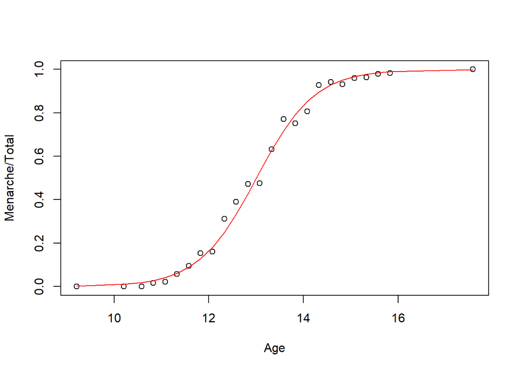

```r
plot(Menarche/Total~Age, data = menarche)
lines(menarche$Age, glm1$fitted.values, type='l', col="red")
```